# Sequence_Analysis_KIFC1_iCLIP

Simona Cantarella, Maïwen Caudron-Herger

2024-05-06

# Set Working Directory

```r
# Set R version -> 4.3.0
setwd('~/Maiwen/postprocessing/REPORT/')
```

# Libraries

```r
# BiocManager::install("BiocStyle")
library(BiocStyle)
library(rtracklayer)
library(ggplot2)
library(BindingSiteFinder) # Install directly from GitHub: install.packages("remotes") and then remotes::install_github("ZarnackGroup/BindingSiteFinder")
library(png)
library(ComplexHeatmap)
library(dplyr)
library(ggpubr)
library(gridExtra)
library(GenomicFeatures)
library(forcats)
library(paletteer)
library(tidyr)
library(GGally)
#
library(BSgenome.Hsapiens.UCSC.hg38)
library(plyranges)
library(ggpubr)
library(ggseqlogo)
library(msa)
library(ggpointdensity)
library(pqsfinder)
library(RColorBrewer)
library(cliProfiler)
library(cowplot)
library(viridis)
library(circlize)
library(knitr)
library(matrixStats)
library(Gviz)
library(ggrepel)
```

# 1 - Load data

## Import the crosslink sites

```r
peak.file="/omics/odcf/analysis/OE0284_projects/clipseq/users/varshni/PureCLIP/unique/PureCLIP.crosslink_sites.bed"
cs = import(con = peak.file, format = "BED",extraCols=c("additionalScores" = "character"))
cs$additionalScores = NULL
cs = keepStandardChromosomes(cs,pruning.mode = "coarse")
cs
```

```
## GRanges object with 345903 ranges and 2 metadata columns:
##            seqnames    ranges strand |        name     score
##               <Rle> <IRanges>  <Rle> | <character> <numeric>
##        [1]     chr1    629571      + |           3   22.6446
##        [2]     chr1    629906      + |           3   71.2317
##        [3]     chr1    629912      + |           3   35.9280
##        [4]     chr1    629915      + |           3   10.2915
##        [5]     chr1    629916      + |           3   16.9593
##        ...      ...       ...    ... .         ...       ...
##   [345899]     chrM       391      - |           3  708.3960
##   [345900]     chrM       305      - |           3   91.0364
##   [345901]     chrM       304      - |           3  708.3960
##   [345902]     chrM       303      - |           3  185.2680
##   [345903]     chrM       200      - |           3   16.3237
##   -------
##   seqinfo: 25 sequences from an unspecified genome; no seqlengths
```

## Import the iCLIP coverage in the form of .bigwig files

```r
mypath <- "/omics/odcf/analysis/OE0284_projects/clipseq/users/varshni/crosslink_nt/unique"
clipFilesP <- list.files(mypath, pattern = "*plus.bw$",full.names = T)
clipFilesP <- clipFilesP[-grep("merge",clipFilesP)]
clipFilesM <- list.files(mypath, pattern = "*minus.bw$",full.names = T)
clipFilesM <- clipFilesM[-grep("merge",clipFilesM)]

meta = data.frame(
  id = c(1:4),
  condition = factor(rep("WT", 4)),
  clPlus = clipFilesP, clMinus = clipFilesM)
meta
```

```
##   id condition
## 1  1        WT
## 2  2        WT
## 3  3        WT
## 4  4        WT
##                                                                                           clPlus
## 1 /omics/odcf/analysis/OE0284_projects/clipseq/users/varshni/crosslink_nt/unique/KIFC1_1.plus.bw
## 2 /omics/odcf/analysis/OE0284_projects/clipseq/users/varshni/crosslink_nt/unique/KIFC1_2.plus.bw
## 3 /omics/odcf/analysis/OE0284_projects/clipseq/users/varshni/crosslink_nt/unique/KIFC1_3.plus.bw
## 4 /omics/odcf/analysis/OE0284_projects/clipseq/users/varshni/crosslink_nt/unique/KIFC1_4.plus.bw
##                                                                                           clMinus
## 1 /omics/odcf/analysis/OE0284_projects/clipseq/users/varshni/crosslink_nt/unique/KIFC1_1.minus.bw
## 2 /omics/odcf/analysis/OE0284_projects/clipseq/users/varshni/crosslink_nt/unique/KIFC1_2.minus.bw
## 3 /omics/odcf/analysis/OE0284_projects/clipseq/users/varshni/crosslink_nt/unique/KIFC1_3.minus.bw
## 4 /omics/odcf/analysis/OE0284_projects/clipseq/users/varshni/crosslink_nt/unique/KIFC1_4.minus.bw
```

## Construct the BSFDataSet object

```r
bds = BSFDataSetFromBigWig(ranges = cs, meta = meta, silent = TRUE)
bds
```

```
##
## Object of class BSFDataSet
## #N Ranges:  345,903
## Width ranges:  1
## #N Samples:  4
## #N Conditions:  1
```

## Construct an annotation comprehensive of repeated elements

```r
# import the Genecode annotation version43
annoFile = "/omics/odcf/analysis/OE0284_projects/clipseq/users/varshni/postprocessing/unique/BindingSiteFinder/gencode.v43.annotation.gff3"
annoInfo = import(annoFile, format = "gff3")
annoInfo = annoInfo[-grep("PAR",annoInfo$ID),] # remove PAR regions

# import repeats annotation
repeats <- read.csv("/omics/odcf/analysis/OE0284_projects/clipseq/users/varshni/prova_rmsk/RepeatMask.csv",sep=",")

# convert the csv file into a GRanges object
repeats <- GRanges(
    seqnames = Rle(repeats$genoName),
    ranges = IRanges(repeats$genoStart, end = repeats$genoEnd),
    strand = Rle(strand(repeats$strand)),
    source = "rmsk",
    type = "gene",
    ID = repeats$repName,
    gene_id = repeats$repName,
    gene_type = repeats$repClass,
    gene_name = repeats$repFamily)

# check duplicated gene types in the Genecode annotation and repeats annotation, and keep the annotation with the highest number of genes
intersect(unique(annoInfo$gene_type),unique(repeats$gene_type))
```

```
## [1] "snRNA" "rRNA"  "scRNA"
```

```r
#length(grep("snRNA",annoInfo$gene_type))
#length(grep("snRNA",repeats$gene_type))
repeats <- repeats[!grepl("snRNA",repeats$gene_type),]  # remove snRNA from the repeats annotation

#length(grep("rRNA",annoInfo$gene_type))
#length(grep("rRNA",repeats$gene_type))
annoInfo <- annoInfo[!grepl("rRNA",annoInfo$gene_type),] # remove rRNA from the gencode annotation

#length(grep("scRNA",annoInfo$gene_type))
#length(grep("scRNA",repeats$gene_type))
annoInfo <- annoInfo[!grepl("scRNA",annoInfo$gene_type),] # remove scRNA from the gencode annotation

# create the final annotation
gencode.v43.repeats <- c(annoInfo,repeats)

# export the final annotation
export(gencode.v43.repeats,"./gencode.v43.repeats.gff3",format = "GFF3")
```

# 2 - Create annotation

## Create annotation for genes

```r
# Load the genecode annotation comprehensive of repeated elements
annoFile = "/omics/odcf/analysis/OE0284_projects/clipseq/users/Maiwen/postprocessing/REPORT/gencode.v43.repeats.gff3"
annoDb = makeTxDbFromGFF(file = annoFile, format = "gff3")
```

```
## Import genomic features from the file as a GRanges object ... OK
## Prepare the 'metadata' data frame ... OK
## Make the TxDb object ...
```

```
## OK
```

```r
annoInfo = import(annoFile, format = "gff3")

# Get genes as GRanges
gns = annoInfo[annoInfo$type=="gene",]
```

## Create annotation for transcript regions

```r
cdseq = cds(annoDb)
intrns = unlist(intronsByTranscript(annoDb))
utrs3 = unlist(threeUTRsByTranscript(annoDb))
utrs5 = unlist(fiveUTRsByTranscript(annoDb))
repeats = granges(annoInfo[annoInfo$source=="rmsk"])
regions = GRangesList(CDS = cdseq, Intron = intrns, UTR3 = utrs3, UTR5 = utrs5, REPEATS=repeats)
regions
```

```
## GRangesList object of length 5:
## $CDS
## GRanges object with 886460 ranges and 4 metadata columns:
##     seqnames        ranges strand |    cds_id   exon_id   exon_name exon_rank
##        <Rle>     <IRanges>  <Rle> | <integer> <integer> <character> <integer>
##         chr1   65565-65573      + |         1      <NA>        <NA>      <NA>
##         chr1   69037-70008      + |         2      <NA>        <NA>      <NA>
##         chr1 924432-924948      + |         3      <NA>        <NA>      <NA>
##         chr1 924432-924948      + |         4      <NA>        <NA>      <NA>
##         chr1 925922-926013      + |         5      <NA>        <NA>      <NA>
##   .      ...           ...    ... .       ...       ...         ...       ...
##         chrM   10470-10766      + |    886456      <NA>        <NA>      <NA>
##         chrM   10760-12137      + |    886457      <NA>        <NA>      <NA>
##         chrM   12337-14148      + |    886458      <NA>        <NA>      <NA>
##         chrM   14747-15887      + |    886459      <NA>        <NA>      <NA>
##         chrM   14149-14673      - |    886460      <NA>        <NA>      <NA>
##   -------
##   seqinfo: 640 sequences (1 circular) from an unspecified genome; no seqlengths
##
## ...
## <4 more elements>
```

# 3 - Define binding sites

## Manually test different binding site sizes

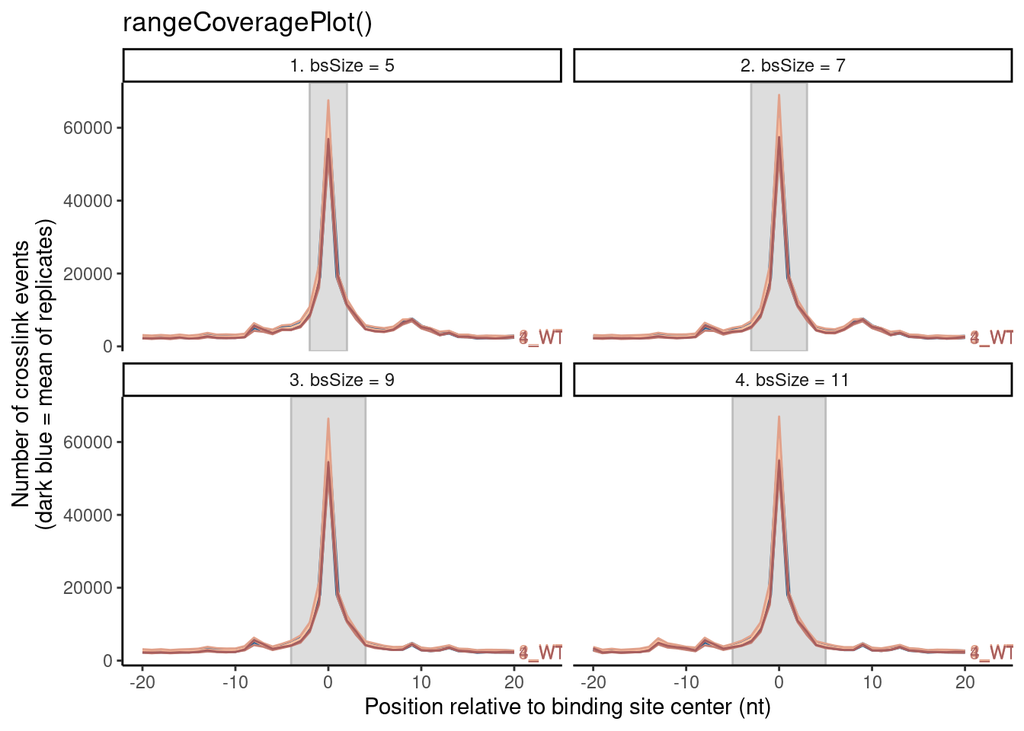

```r
# compute binding sites
bds1 <- makeBindingSites(object = bds, bsSize = 5)
bds2 <- makeBindingSites(object = bds, bsSize = 7)
bds3 <- makeBindingSites(object = bds, bsSize = 9)
bds4 <- makeBindingSites(object = bds, bsSize = 11)

# summarize in list
l = list(`1. bsSize = 5` = bds1, `2. bsSize = 7` = bds2,
         `3. bsSize = 9` = bds3, `4. bsSize = 11` = bds4)
rangeCoveragePlot(l, width = 20, show.samples = TRUE)
```

Suggested: 7 nt (a bit more toward background level, without reaching it). We can also run the function BSFind and check the suggested parameters

## Make binding sites (use bsResolution=fine)

```
## Fixed signal input, removing chr: chr10 chr11 chr12 chr13 chr14 chr15 chr16 chr17 chr18 chr19 chr2 chr20 chr21 chr22 chr3 chr4 chr5 chr6 chr7 chr8 chr9 chrM chrX chrY
```

```
## 14.77% (5363/36301) peaks overlap with multiple anno.genes in the given gene annotation.
## A single instance of each peak is kept. This is recommended.
##
```

[output not shown]

```
## 11.75% (4265/36301) peaks overlap with multiple anno.genes in the given gene annotation.
## A single instance of each peak is kept. This is recommended.
##
```

[output not shown]

```
## 10.47% (3802/36301) peaks overlap with multiple anno.genes in the given gene annotation.
## A single instance of each peak is kept. This is recommended.
##
```

[output not shown]

```
## 9.07% (3292/36301) peaks overlap with multiple anno.genes in the given gene annotation.
## A single instance of each peak is kept. This is recommended.
##
```

[output not shown]

```
## 7.77% (2819/36301) peaks overlap with multiple anno.genes in the given gene annotation.
## A single instance of each peak is kept. This is recommended.
##
```

[output not shown]

```
## 6.64% (2411/36301) peaks overlap with multiple anno.genes in the given gene annotation.
## A single instance of each peak is kept. This is recommended.
##
```

[output not shown]

```
## 5.14% (1865/36301) peaks overlap with multiple anno.genes in the given gene annotation.
## A single instance of each peak is kept. This is recommended.
##
```

[output not shown]

```
## 3.93% (1425/36301) peaks overlap with multiple anno.genes in the given gene annotation.
## A single instance of each peak is kept. This is recommended.
##
```

[output not shown]

```
## 2.79% (1014/36301) peaks overlap with multiple anno.genes in the given gene annotation.
## A single instance of each peak is kept. This is recommended.
##
```

[output not shown]

```
## 1.65% (600/36301) peaks overlap with multiple anno.genes in the given gene annotation.
## A single instance of each peak is kept. This is recommended.
##
```

[output not shown]

```
## 5.01% (17171/342455) peaks overlap with multiple anno.genes in the given gene annotation.
## A single instance of each peak is kept. This is recommended.
##
```

```
## Reproducibility cutoff not defined. Defaults to 0.05 for each condition.
```

```
## Parameter nReps not defined. Defaults to N-1 for each condition.
```

```
## 17.55% (3310/18856) of binding sites overlap with multiple anno.genes in the given gene annotation.
## Apply 'frequency' solution
```

```
## 30.87% (6509/21082) of binding sites overlap with multiple different transcript regions in the given annotation.
## Apply 'frequency' solution.
##
```

### Check results of the function with a graphical representation

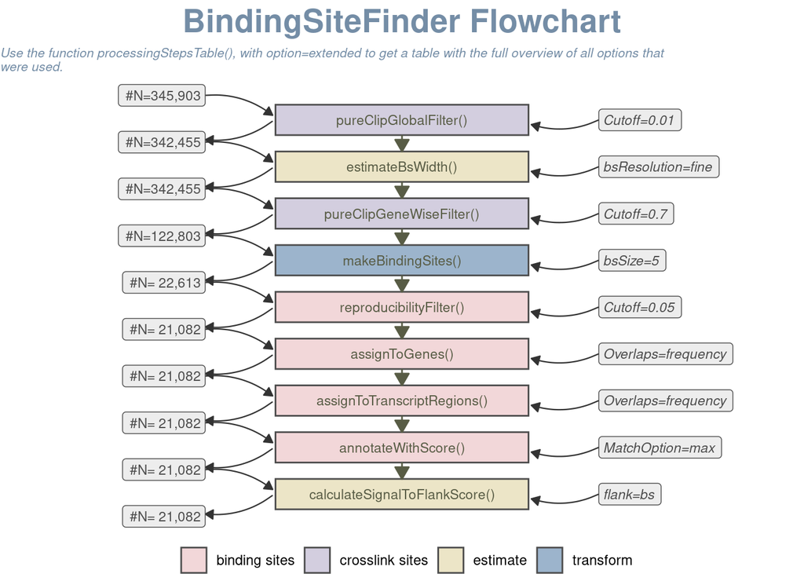

```r
processingStepsFlowChart(bdsOut)
```

### Estimate width manually

```
## Estimation at: 0%
```

```
## Estimation at: 10%
```

```
## Estimation at: 20%
```

```
## Estimation at: 30%
```

```
## Estimation at: 40%
```

```
## Estimation at: 50%
```

```
## Estimation at: 60%
```

```
## Estimation at: 70%
```

```
## Estimation at: 80%
```

```
## Estimation at: 90%
```

```
## Estimation at: 100%
```

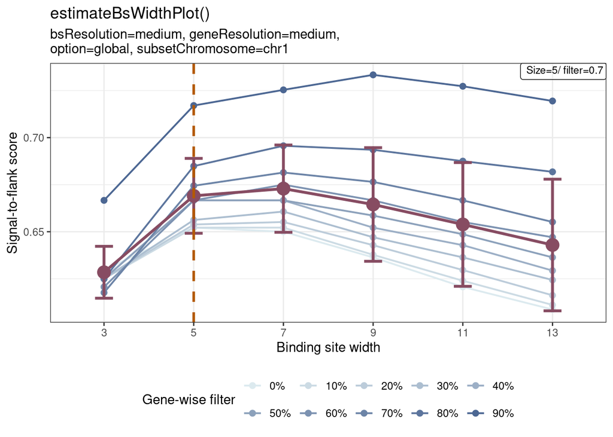

```r
estimateBsWidthPlot(estimateBsWidth(object = bds, anno.genes = gns, anno.transcriptRegionList = regions))
```

I would suggest to use a gene-wise (GW) filter of 50%, using a binding size of 7 nt.

## Make binding sites (use bsResolution=fine)

```r
# Use 7 nt bsSize and 50% geneWise filter
bdsOut_7nt_GW = BSFind(object = bds, anno.genes = gns, anno.transcriptRegionList = regions, veryQuiet = TRUE, est.maxBsWidth = 29, bsSize = 7, cutoff.geneWiseFilter = 0.5, est.bsResolution = "fine")
```

```
## 8.8% (30147/342455) peaks overlap with multiple anno.genes in the given gene annotation.
## A single instance of each peak is kept. This is recommended.
##
```

```
## Reproducibility cutoff not defined. Defaults to 0.05 for each condition.
```

```
## Parameter nReps not defined. Defaults to N-1 for each condition.
```

```
## 17.11% (5905/34512) of binding sites overlap with multiple anno.genes in the given gene annotation.
## Apply 'frequency' solution
```

```
## 32.7% (12077/36934) of binding sites overlap with multiple different transcript regions in the given annotation.
## Apply 'frequency' solution.
##
```

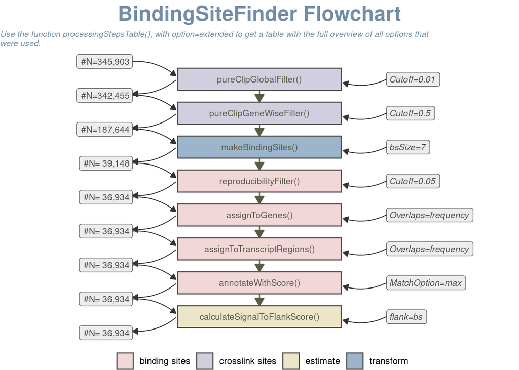

```r
processingStepsFlowChart(bdsOut_7nt_GW)
```

# 4 - Summary plots

## PureCLIP filter 1%

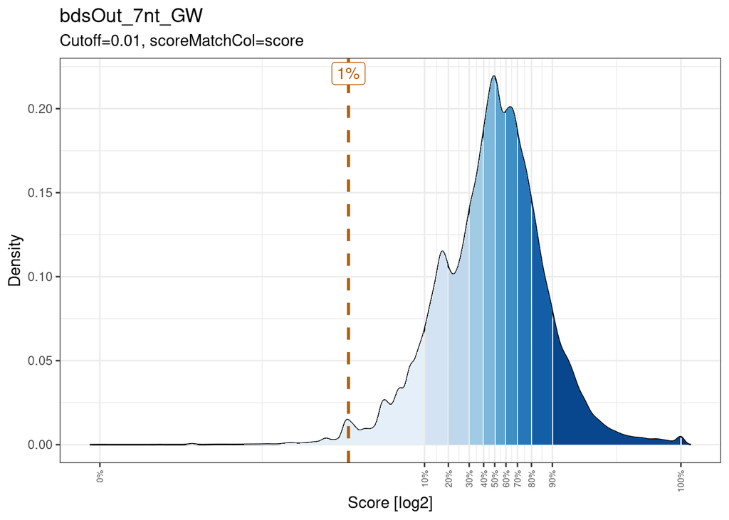

```r
pureClipGlobalFilterPlot(bdsOut_7nt_GW) + ggtitle("bdsOut_7nt_GW")
```

## Plots duplicated sites

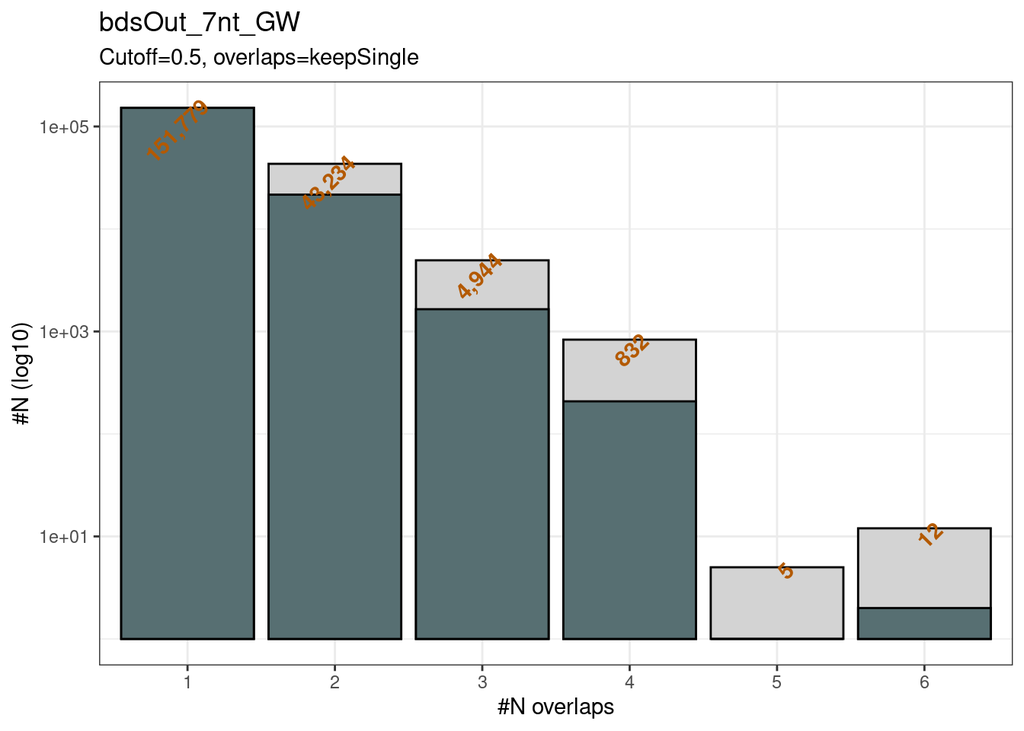

```r
duplicatedSitesPlot(bdsOut_7nt_GW) + ggtitle("bdsOut_7nt_GW")
```

## Merge crosslink sites into binding sites

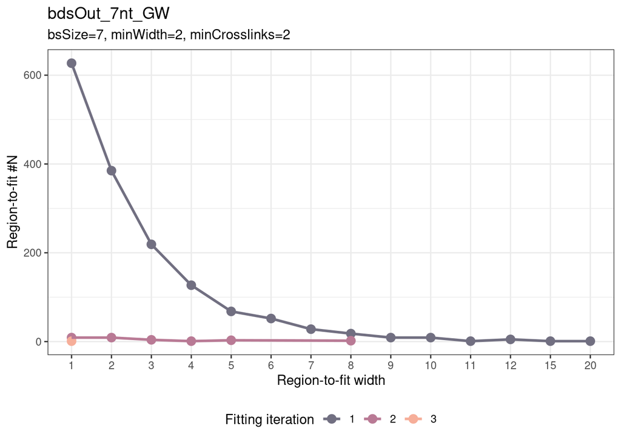

```r
mergeCrosslinkDiagnosticsPlot(bdsOut_7nt_GW) + ggtitle("bdsOut_7nt_GW")
```

## Number of binding sites after the various selection steps

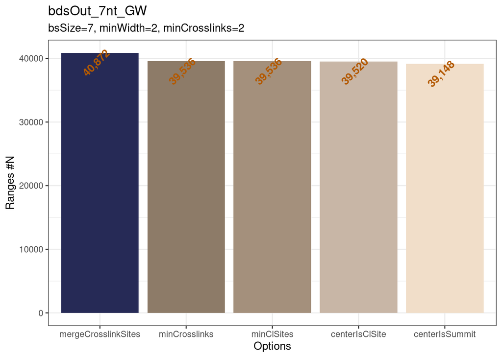

```r
makeBsSummaryPlot(bdsOut_7nt_GW) + ggtitle("bdsOut_7nt_GW")
```

## Replicates reproducibility

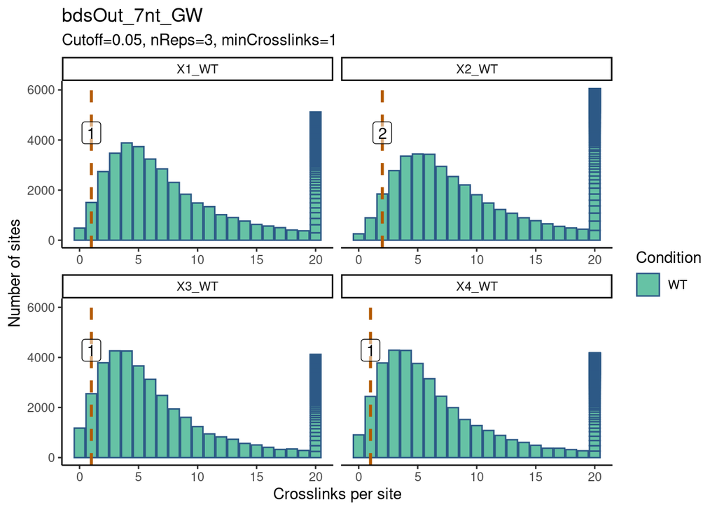

```r
reproducibilityFilterPlot(bdsOut_7nt_GW) + ggtitle("bdsOut_7nt_GW")
```

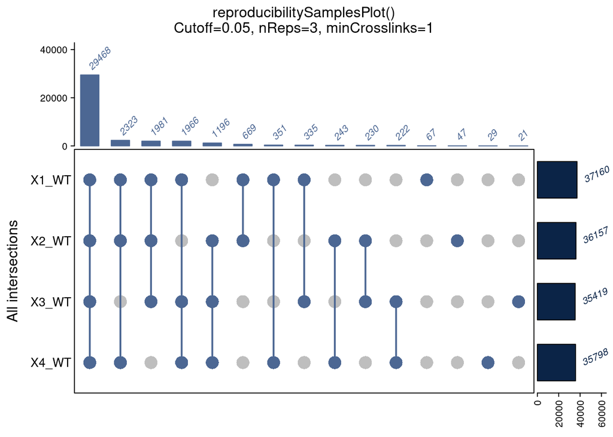

```r
reproducibilitySamplesPlot(bdsOut_7nt_GW) + ggtitle("bdsOut_7nt_GW")
```

29468 binding sites in common out of 36934. It is 79.8% of the selected binding sites. 36934 is the number of binding sites which are in common for at least 3 replicates (= 3 or 4).

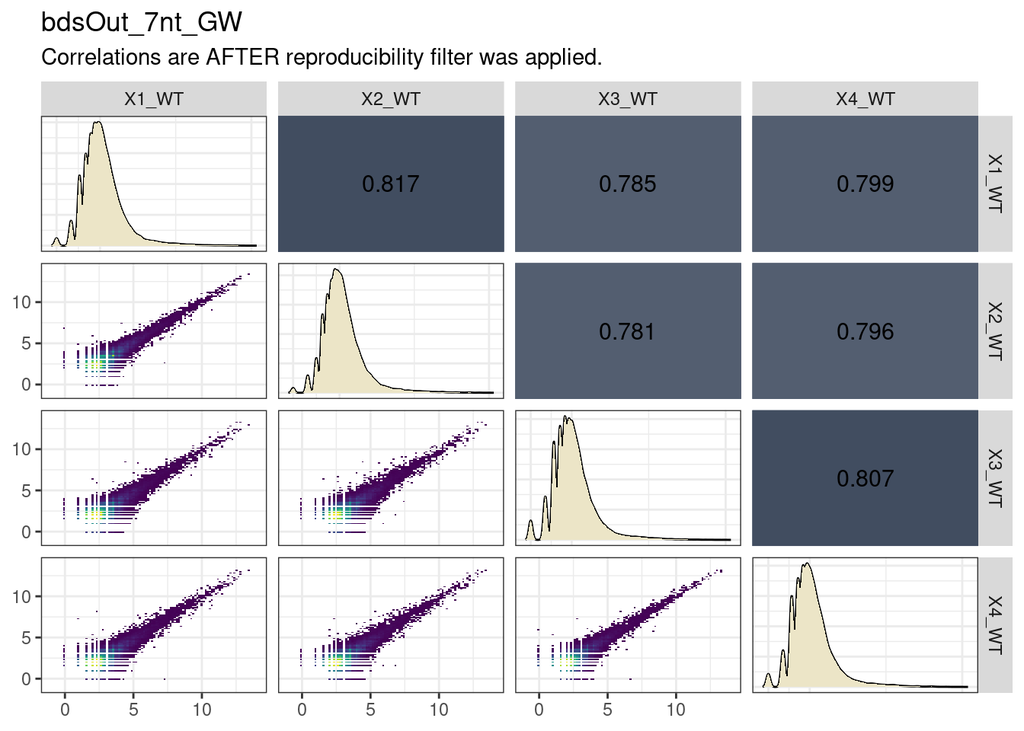

```r
reproducibilityScatterPlot(bdsOut_7nt_GW) + ggtitle("bdsOut_7nt_GW")
```

Pairwise Pearson’s correlation are good. All > 0.78.

# 5 -Genomic target identification

## Target gene identification

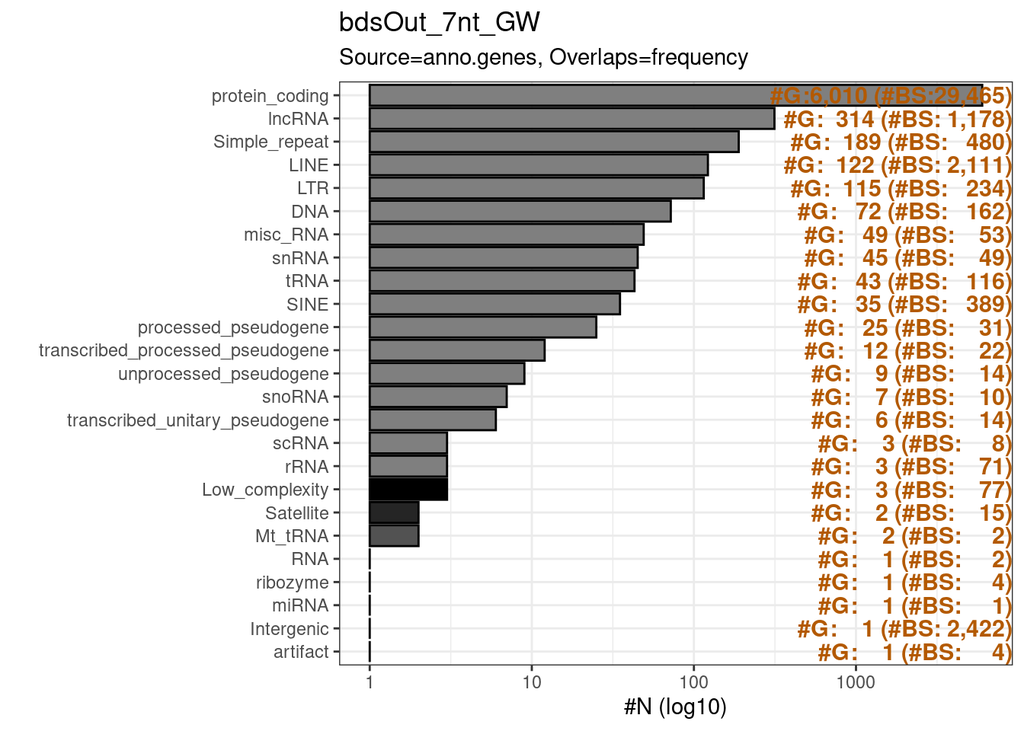

```r
targetGeneSpectrumPlot(bdsOut_7nt_GW, showNGroups = nrow(bdsOut_7nt_GW@plotData$assignToGenes$dataSpectrum)) + ggtitle("bdsOut_7nt_GW")
```

## Transcript region identification

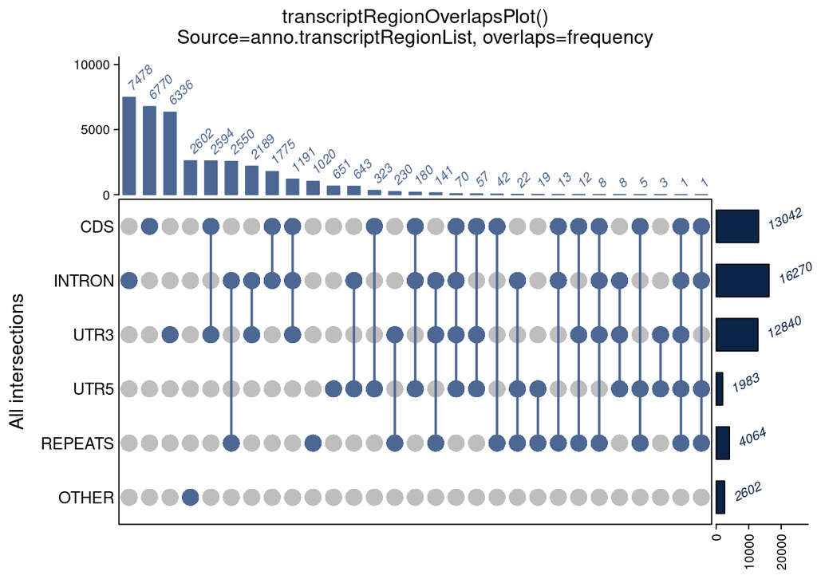

```r
transcriptRegionOverlapsPlot(bdsOut_7nt_GW) + ggtitle("bdsOut_7nt_GW")
```

## Transcript region spectrum, normalized to summed length

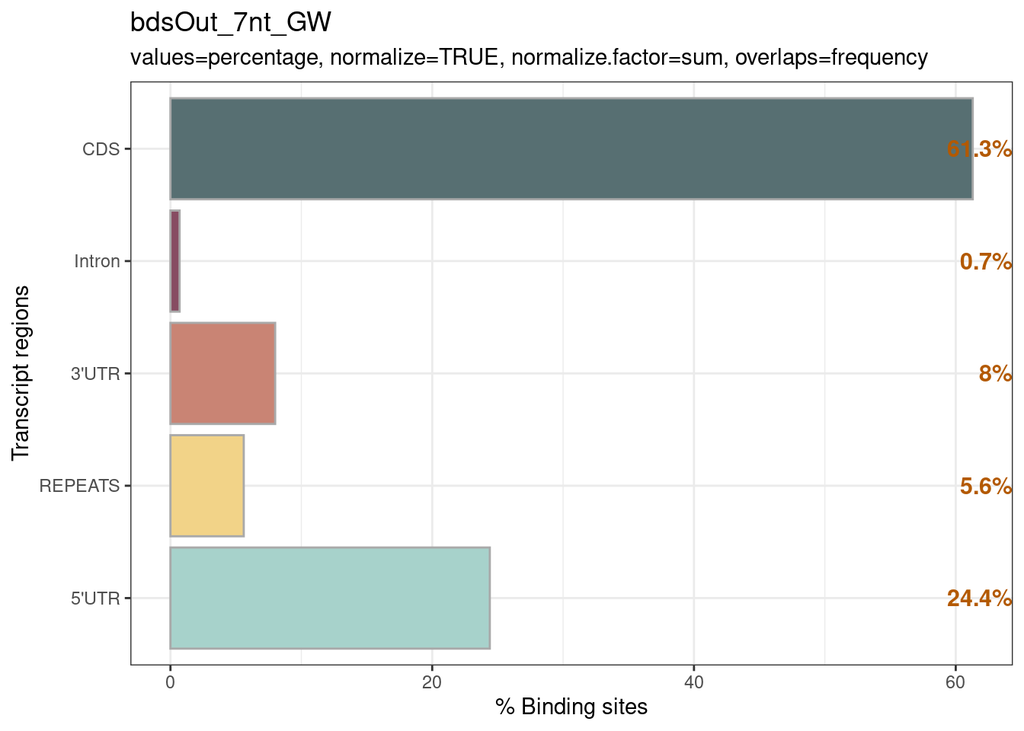

```r
transcriptRegionSpectrumPlot(bdsOut_7nt_GW,normalize = T, values = "percentage") + ggtitle("bdsOut_7nt_GW")
```

## Binding site definedness

How well the defined binding sites fit to the observed crosslink coverage can be assess through binding site definedness. This also gives first insights into the overall binding site shape and the binding mode of the RBP. Here we assess this property through a percent bound score, that divides the number of crosslinks inside the binding sites by the total number of crosslinks in a region around the binding site. As default, this background region is two times the size of the binding site. In other words, we compare the signal within a binding site to a same sized window directly flanking the binding site on both sides.

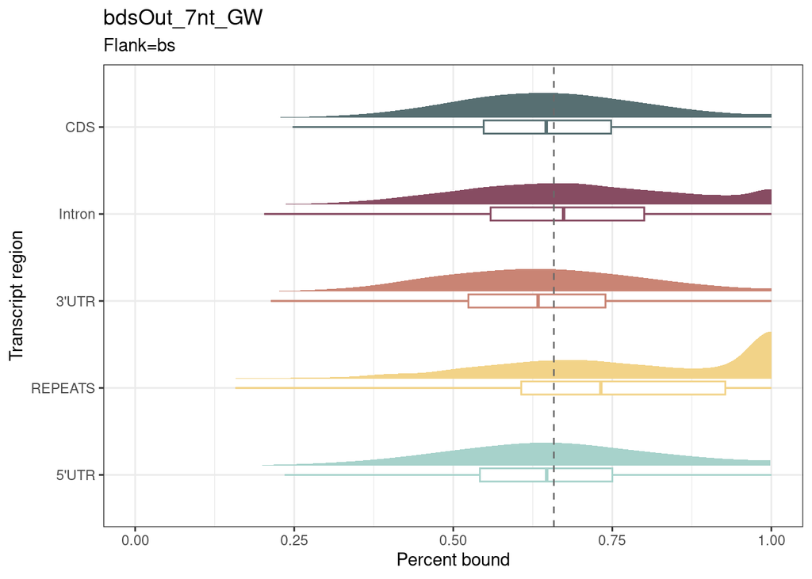

```r
bindingSiteDefinednessPlot(bdsOut_7nt_GW, by = "transcript") + ggtitle("bdsOut_7nt_GW")
```

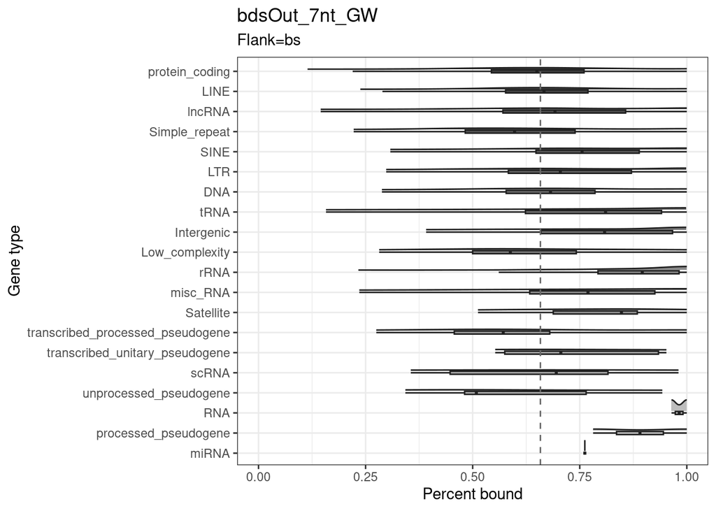

```r
bindingSiteDefinednessPlot(bdsOut_7nt_GW, showN.genes=nrow(bdsOut_7nt_GW@plotData$assignToGenes$dataSpectrum), by = "gene_type") + ggtitle("bdsOut_7nt_GW")
```

# 6 - Binding site strength - filter the tails

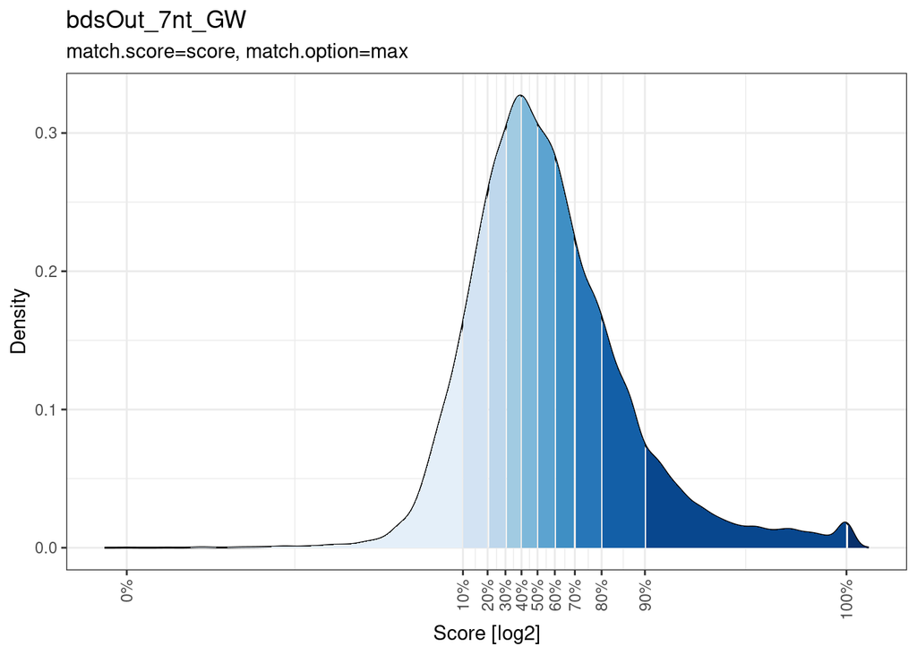

```r
globalScorePlot(bdsOut_7nt_GW) + ggtitle("bdsOut_7nt_GW")
```

# 7 - Get Ranges

```r
bs_7nt_GW <- getRanges(bdsOut_7nt_GW)
bs_7nt_GW[order(bs_7nt_GW$score,decreasing = T),]
```

```
## GRanges object with 36934 ranges and 9 metadata columns:
##         seqnames              ranges strand |        bsID    bsSize   currIdx
##            <Rle>           <IRanges>  <Rle> | <character> <numeric> <integer>
##      81     chr1   11908147-11908153      + |        BS87         7        74
##     118     chr1   16872579-16872585      + |       BS126         7       110
##     119     chr1   16872613-16872619      + |       BS127         7       111
##     207     chr1   28507361-28507367      + |       BS217         7       194
##     208     chr1   28507385-28507391      + |       BS218         7       195
##     ...      ...                 ...    ... .         ...       ...       ...
##   21795    chr11   66104856-66104862      + |     BS22683         7     20461
##   24583    chr12 122075544-122075550      + |     BS25585         7     23115
##   18729     chr9   11044699-11044705      - |     BS19493         7     17583
##   23525    chr12     9179754-9179760      + |     BS24479         7     22098
##   32655    chr17   50151030-50151036      - |     BS33986         7     30699
##                     geneID        geneName       geneType transcriptRegion
```

[output cut: 27 more lines]

## Filter out bottom and top 5%

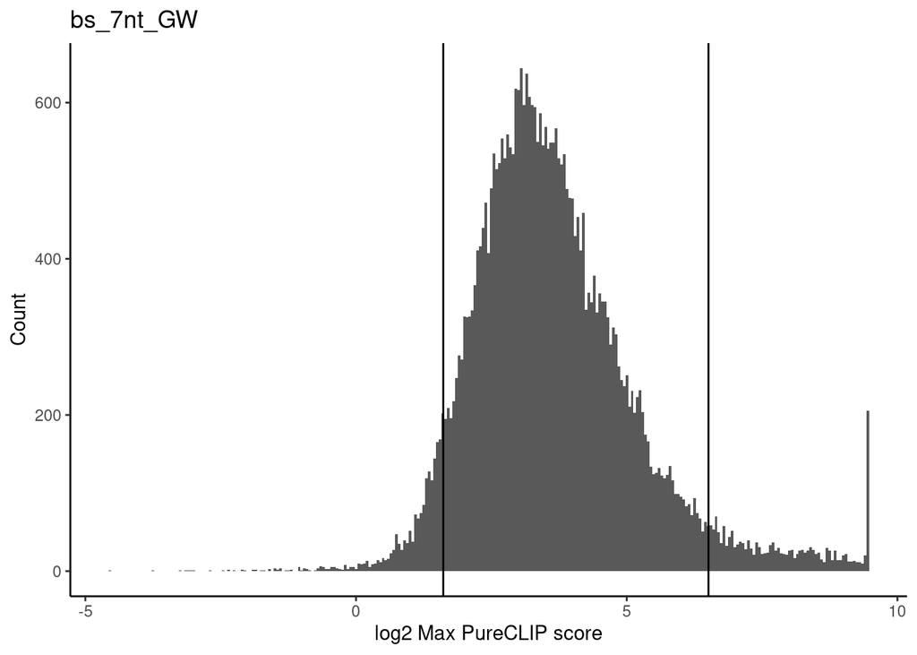

```r
#Filter out lower and higher 5%
quants = quantile(bs_7nt_GW$score, probs = seq(0,1, by = 0.05))
ggplot(data = data.frame(score = bs_7nt_GW$score), aes(x = log2(score))) +
    geom_histogram(binwidth = 0.05) +
    geom_vline(xintercept = c(log2(quants[2]),log2(quants[20]))) +
    theme_classic() +
    xlab("log2 Max PureCLIP score") +
    ylab("Count")+
   ggtitle("bs_7nt_GW")
```

```r
bs_7nt_GW = bs_7nt_GW[bs_7nt_GW$score >= quants[2]&bs_7nt_GW$score <= quants[20]]
```

# 8 - Add CLIP coverage

```r
bs_7nt_GW = clipCoverage(bdsOut_7nt_GW, ranges.merge = TRUE, samples.merge = FALSE, positions.merge = FALSE)
bs_7nt_GW # 36934 ranges
```

```
## GRanges object with 36934 ranges and 13 metadata columns:
##           seqnames        ranges strand |        bsID    bsSize   currIdx
##              <Rle>     <IRanges>  <Rle> | <character> <numeric> <integer>
##       BS1     chr1 629903-629909      + |         BS1         7         1
##       BS2     chr1 629922-629928      + |         BS2         7         2
##       BS3     chr1 629930-629936      + |         BS3         7         3
##       BS4     chr1 630724-630730      + |         BS4         7         4
##       BS5     chr1 631376-631382      + |         BS5         7         5
##       ...      ...           ...    ... .         ...       ...       ...
##   BS40868     chrM   15861-15867      - |     BS40868         7     36930
##   BS40869     chrM   15988-15994      - |     BS40869         7     36931
##   BS40870     chrM   16273-16279      - |     BS40870         7     36932
##   BS40871     chrM   16461-16467      - |     BS40871         7     36933
##   BS40872     chrM   16553-16559      - |     BS40872         7     36934
##                      geneID    geneName               geneType transcriptRegion
##                 <character> <character>            <character>      <character>
##       BS1 ENSG00000225630.1    MTND2P28 unprocessed_pseudogene            OTHER
##       BS2 ENSG00000225630.1    MTND2P28 unprocessed_pseudogene            OTHER
##       BS3 ENSG00000225630.1    MTND2P28 unprocessed_pseudogene            OTHER
##       BS4              <NA>        <NA>             Intergenic            OTHER
##       BS5 ENSG00000237973.1    MTCO1P12 unprocessed_pseudogene            OTHER
##       ...               ...         ...                    ...              ...
##   BS40868              <NA>        <NA>             Intergenic            OTHER
##   BS40869 ENSG00000210196.2       MT-TP                Mt_tRNA            OTHER
##   BS40870              <NA>        <NA>             Intergenic            OTHER
##   BS40871              <NA>        <NA>             Intergenic            OTHER
##   BS40872              <NA>        <NA>             Intergenic            OTHER
##               score signalToFlankRatio      1_WT      2_WT      3_WT      4_WT
##           <numeric>          <numeric> <numeric> <numeric> <numeric> <numeric>
##       BS1   71.2317           0.406452        42        39        20        25
##       BS2   98.0579           0.365127        94        73        38        40
##       BS3  147.6260           0.490760        80        80        37        42
##       BS4   40.2829           0.527027         9         9        13         8
##       BS5   21.8007           0.282230        18        16        23        24
##       ...       ...                ...       ...       ...       ...       ...
##   BS40868  97.49160           0.498258        86        71        62        67
##   BS40869 708.39600           0.832919       916      1046       896      1160
##   BS40870  35.77820           0.605839        25        36        13         9
##   BS40871   9.12546           0.723077        19         9         9        10
##   BS40872  32.49680           0.663043        13        27        11        10
##   -------
##   seqinfo: 25 sequences from an unspecified genome; no seqlengths
```

```r
# Store separately the TOP 5% BS
bs_7nt_GW_TOP5 <- bs_7nt_GW[bs_7nt_GW$score >= quants[20]]
bs_7nt_GW_TOP5
```

```
## GRanges object with 1847 ranges and 13 metadata columns:
##           seqnames            ranges strand |        bsID    bsSize   currIdx
##              <Rle>         <IRanges>  <Rle> | <character> <numeric> <integer>
##       BS2     chr1     629922-629928      + |         BS2         7         2
##       BS3     chr1     629930-629936      + |         BS3         7         3
##      BS87     chr1 11908147-11908153      + |        BS87         7        74
##      BS88     chr1 11908191-11908197      + |        BS88         7        75
##     BS123     chr1 16727272-16727278      + |       BS123         7       107
##       ...      ...               ...    ... .         ...       ...       ...
##   BS40856     chrM       12748-12754      - |     BS40856         7     36918
##   BS40862     chrM       13611-13617      - |     BS40862         7     36924
##   BS40864     chrM       14536-14542      - |     BS40864         7     36926
##   BS40868     chrM       15861-15867      - |     BS40868         7     36930
##   BS40869     chrM       15988-15994      - |     BS40869         7     36931
##                      geneID        geneName               geneType
##                 <character>     <character>            <character>
##       BS2 ENSG00000225630.1        MTND2P28 unprocessed_pseudogene
##       BS3 ENSG00000225630.1        MTND2P28 unprocessed_pseudogene
##      BS87 ENSG00000285646.2 ENSG00000285646                 lncRNA
##      BS88 ENSG00000285646.2 ENSG00000285646                 lncRNA
##     BS123              <NA>            <NA>             Intergenic
##       ...               ...             ...                    ...
##   BS40856              <NA>            <NA>             Intergenic
##   BS40862              <NA>            <NA>             Intergenic
##   BS40864 ENSG00000198695.2          MT-ND6         protein_coding
##   BS40868              <NA>            <NA>             Intergenic
##   BS40869 ENSG00000210196.2           MT-TP                Mt_tRNA
##           transcriptRegion     score signalToFlankRatio      1_WT      2_WT
##                <character> <numeric>          <numeric> <numeric> <numeric>
##       BS2            OTHER   98.0579           0.365127        94        73
##       BS3            OTHER  147.6260           0.490760        80        80
##      BS87            OTHER  708.3960           0.977650       969       959
##      BS88            OTHER  610.4900           0.630577       252       318
##     BS123            OTHER  166.8310           0.783862        66        73
##       ...              ...       ...                ...       ...       ...
##   BS40856            OTHER  133.1100           0.327782       112       127
##   BS40862            OTHER  288.6890           0.744310       253       279
##   BS40864              CDS  109.1950           0.537984       369       469
##   BS40868            OTHER   97.4916           0.498258        86        71
##   BS40869            OTHER  708.3960           0.832919       916      1046
##                3_WT      4_WT
##           <numeric> <numeric>
##       BS2        38        40
##       BS3        37        42
##      BS87       695       789
##      BS88       228       262
##     BS123        67        66
##       ...       ...       ...
##   BS40856        99        95
##   BS40862       258       191
##   BS40864       270       280
##   BS40868        62        67
##   BS40869       896      1160
##   -------
##   seqinfo: 25 sequences from an unspecified genome; no seqlengths
```

```r
# Remove top and bottom 5%
#bs_7nt_GW = bs_7nt_GW[bs_7nt_GW$score >= quants[2]&bs_7nt_GW$score <= quants[20]]
#bs_7nt_GW # 33240 ranges
```

# Export the results

```r
# As rds
saveRDS(bs_7nt_GW,file="bs_7nt_GW.rds")
saveRDS(bdsOut_7nt_GW,file="bdsOut_7nt_GW.rds")

# As bed
export(bs_7nt_GW,"bs_7nt_GW.bed",format="BED")

# Free environment
rm(list=ls())
```